# Spiders update

Pedro Santos Neves

28/01/2022

```r
knitr::kable(res) %>% kableExtra::kable_styling()
```

| scenario | lambda_c | mu | K | gamma | lambda_a | loglik | df | conv | bic | integrator |
| --- | --- | --- | --- | --- | --- | --- | --- | --- | --- | --- |
| r_c_max | 0.7880373 | 0.0000012 | 1.999999e+00 | 0.2578952 | 0.6488123 | -148.4772 | 5 | 0 | 331.7636 | odeint |
| r_c_min | 0.8429674 | 0.0000000 | 2.000000e+00 | 0.2514304 | 0.6960577 | -157.0194 | 5 | 0 | 348.8480 | odeint |
| r_c_no | 0.6755568 | 0.0000000 | 2.000000e+00 | 0.2595973 | 0.5800877 | -145.8492 | 5 | 0 | 326.5076 | odeint |
| y_c_max | 0.4866820 | 1.3995372 | 4.000000e+00 | 0.4423810 | 0.4721161 | -159.4910 | 5 | 0 | 353.7911 | odeint |
| y_c_min | 0.4574419 | 0.0000004 | 1.999994e+00 | 0.1244317 | 0.2743426 | -178.8182 | 5 | 0 | 392.4455 | odeint |
| y_c_no | 64.0606640 | 0.0000015 | 1.001937e+00 | 0.1410927 | 0.2598607 | -164.2307 | 5 | 0 | 363.2706 | odeint |
| o_c_max | 0.3295038 | 1.0752982 | 4.000000e+00 | 0.3496884 | 0.4619606 | -167.0019 | 5 | 0 | 368.8129 | odeint |
| o_c_min | 0.2604294 | 0.2858229 | 4.000000e+00 | 0.1247982 | 0.1696735 | -193.2664 | 5 | 0 | 421.3420 | odeint |
| o_c_no | 0.1622019 | 0.1871203 | 2.000000e+00 | 0.1324520 | 0.2058471 | -181.2004 | 5 | 0 | 397.2099 | odeint |
| a_c_max | 0.3373815 | 1.1606267 | 5.000000e+00 | 0.3634521 | 0.4584703 | -167.0781 | 5 | 0 | 368.9655 | odeint |
| a_c_min | 0.2450561 | 0.4574240 | 4.000000e+00 | 0.1408056 | 0.1315115 | -201.7550 | 5 | 0 | 438.3193 | odeint |
| a_c_no | 0.1275702 | 0.3991600 | 3.000000e+00 | 0.1643005 | 0.1599706 | -190.5543 | 5 | 0 | 415.9179 | odeint |
| r_m_max | 0.6586701 | 0.0000013 | 2.000000e+00 | 0.2711287 | 0.6983693 | -154.3252 | 5 | 0 | 343.4596 | odeint |
| r_m_min | 0.7174805 | 0.0000000 | 2.000000e+00 | 0.2635807 | 0.7614844 | -164.5185 | 5 | 0 | 363.8463 | odeint |
| r_m_no | 0.5687080 | 0.0000002 | 2.000000e+00 | 0.2719647 | 0.6453221 | -153.2129 | 5 | 0 | 341.2350 | odeint |
| y_m_max | 0.4301914 | 1.9004336 | 4.000000e+00 | 0.6281432 | 0.7291830 | -157.2212 | 5 | 0 | 349.2517 | odeint |
| y_m_min | 0.2349884 | 0.0000011 | 2.999999e+00 | 0.1295765 | 0.3555958 | -188.3829 | 5 | 0 | 411.5749 | odeint |
| y_m_no | 0.1493984 | 0.0000009 | 2.000001e+00 | 0.1456066 | 0.2969005 | -169.8218 | 5 | 0 | 374.4529 | odeint |
| o_m_max | 0.2421241 | 1.2282980 | 4.000000e+00 | 0.4275111 | 0.6030099 | -165.0125 | 5 | 0 | 364.8341 | odeint |
| o_m_min | 0.2248486 | 0.4086111 | 4.000001e+00 | 0.1573977 | 0.2525849 | -202.6950 | 5 | 0 | 440.1993 | odeint |
| o_m_no | 0.0978860 | 0.2637978 | 2.000000e+00 | 0.1593630 | 0.2409364 | -185.3848 | 5 | 0 | 405.5788 | odeint |
| a_m_max | 0.2346612 | 1.2426279 | 4.000000e+00 | 0.4277662 | 0.6080374 | -165.0613 | 5 | 0 | 364.9318 | odeint |
| a_m_min | 0.1903731 | 0.5245461 | 5.000001e+00 | 0.1665513 | 0.2164757 | -211.1105 | 5 | 0 | 457.0301 | odeint |
| a_m_no | 0.0650702 | 0.3892583 | 2.000001e+00 | 0.1733342 | 0.2162294 | -194.0817 | 5 | 0 | 422.9726 | odeint |
| r_c_max | 0.7879782 | 0.0000001 | 2.000000e+00 | 0.2579033 | 0.6487746 | -148.4772 | 5 | 0 | 331.7636 | lsodes |
| r_c_min | 0.8429267 | 0.0000000 | 2.000000e+00 | 0.2514270 | 0.6960544 | -157.0194 | 5 | 0 | 348.8480 | lsodes |
| r_c_no | 0.6756321 | 0.0000002 | 2.000000e+00 | 0.2596021 | 0.5801880 | -145.8492 | 5 | 0 | 326.5076 | lsodes |
| y_c_max | 0.4866594 | 1.3995462 | 4.000000e+00 | 0.4423710 | 0.4721158 | -159.4910 | 5 | 0 | 353.7911 | lsodes |
| y_c_min | 0.4574549 | 0.0000000 | 1.999994e+00 | 0.1244134 | 0.2743595 | -178.8182 | 5 | 0 | 392.4455 | lsodes |
| y_c_no | 136.7950936 | 0.0000034 | 1.000905e+00 | 0.1411300 | 0.2598801 | -164.2290 | 5 | 0 | 363.2673 | lsodes |
| o_c_max | 0.3294924 | 1.0754289 | 4.000000e+00 | 0.3497557 | 0.4619698 | -167.0019 | 5 | 0 | 368.8129 | lsodes |
| o_c_min | 0.2603612 | 0.2853951 | 4.000000e+00 | 0.1247190 | 0.1697009 | -193.2664 | 5 | 0 | 421.3420 | lsodes |
| o_c_no | 0.1621859 | 0.1871175 | 2.000000e+00 | 0.1324512 | 0.2058365 | -181.2004 | 5 | 0 | 397.2099 | lsodes |
| a_c_max | 0.3376080 | 1.1611729 | 5.000000e+00 | 0.3636241 | 0.4586448 | -167.0781 | 5 | 0 | 368.9655 | lsodes |
| a_c_min | 0.2450613 | 0.4573151 | 4.000000e+00 | 0.1408174 | 0.1314927 | -201.7550 | 5 | 0 | 438.3193 | lsodes |
| a_c_no | 0.1275402 | 0.3990918 | 3.000004e+00 | 0.1643016 | 0.1599201 | -190.5543 | 5 | 0 | 415.9179 | lsodes |
| r_m_max | 0.6586749 | 0.0000000 | 2.000000e+00 | 0.2711153 | 0.6983830 | -154.3252 | 5 | 0 | 343.4596 | lsodes |
| r_m_min | 0.2368051 | 0.0000000 | 1.339731e+05 | 0.2558096 | 0.8099925 | -165.3197 | 5 | 0 | 365.4485 | lsodes |
| r_m_no | 0.5687905 | 0.0000000 | 2.000000e+00 | 0.2719660 | 0.6454128 | -153.2129 | 5 | 0 | 341.2350 | lsodes |
| y_m_max | 0.4300281 | 1.8998436 | 4.000000e+00 | 0.6279918 | 0.7290212 | -157.2212 | 5 | 0 | 349.2517 | lsodes |
| y_m_min | 0.2349532 | 0.0000003 | 2.999987e+00 | 0.1295600 | 0.3556159 | -188.3829 | 5 | 0 | 411.5749 | lsodes |
| y_m_no | 0.1495587 | 0.0000001 | 2.000001e+00 | 0.1456173 | 0.2968671 | -169.8218 | 5 | 0 | 374.4529 | lsodes |
| o_m_max | 0.2420473 | 1.2283591 | 4.000000e+00 | 0.4275134 | 0.6030654 | -165.0125 | 5 | 0 | 364.8341 | lsodes |
| o_m_min | 0.2250008 | 0.4095354 | 4.000000e+00 | 0.1575711 | 0.2525690 | -202.6950 | 5 | 0 | 440.1993 | lsodes |
| o_m_no | 0.0978968 | 0.2637937 | 2.000000e+00 | 0.1593606 | 0.2409330 | -185.3848 | 5 | 0 | 405.5788 | lsodes |
| a_m_max | 0.2344582 | 1.2416462 | 4.000002e+00 | 0.4274046 | 0.6077437 | -165.0613 | 5 | 0 | 364.9318 | lsodes |
| a_m_min | 0.1904083 | 0.5245422 | 5.000003e+00 | 0.1665421 | 0.2164356 | -211.1105 | 5 | 0 | 457.0301 | lsodes |
| a_m_no | 0.0651300 | 0.3891852 | 2.000000e+00 | 0.1733006 | 0.2161989 | -194.0817 | 5 | 0 | 422.9726 | lsodes |

```r
facs <- sapply(res$scenario, strsplit, split = "_")
expanded_table <- cbind(res, "island_age", "c_m", "stac")
for (i in seq_along(facs)) {
  expanded_table$`"island_age"`[i] <- facs[[i]][1]
  expanded_table$`"c_m"`[i] <- facs[[i]][2]
  expanded_table$`"stac"`[i] <- facs[[i]][3]
}
expanded_table$`"island_age"` <- factor(
  expanded_table$`"island_age"`,
  levels = c("r", "y", "o", "a")
)
expanded_table_odeint <- subset(
  x = expanded_table,
  expanded_table$integrator == "odeint"
)
```

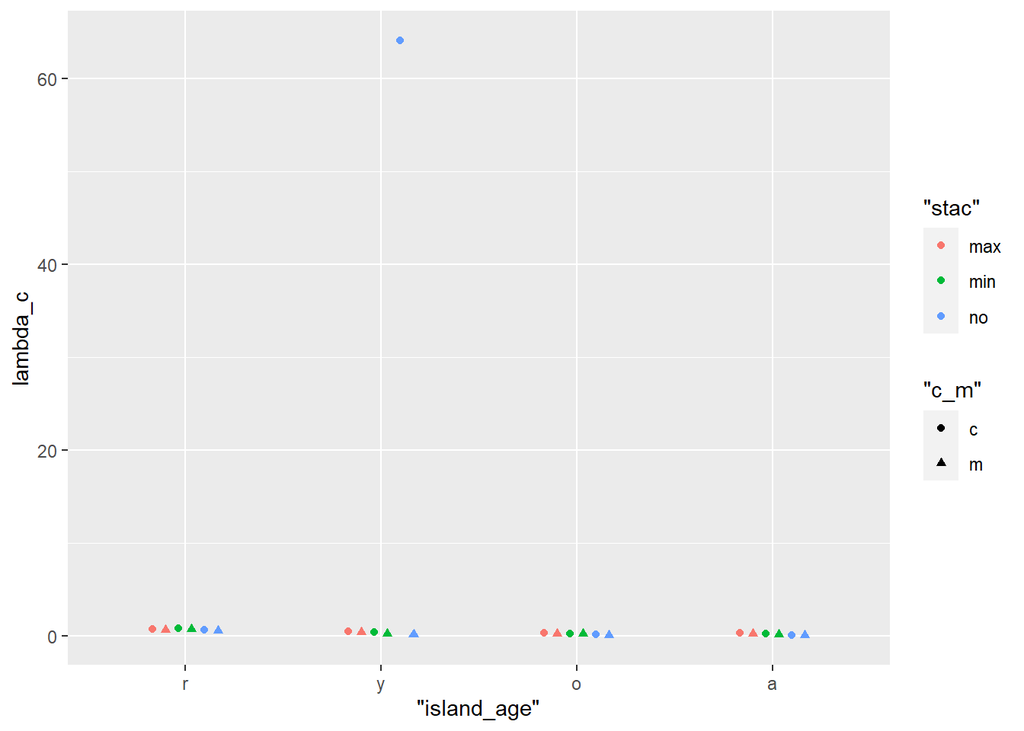

```r
ggplot2::ggplot(expanded_table_odeint, aes(x = `"island_age"`, y = lambda_c)) +
  geom_point(aes(color = `"stac"`, shape = `"c_m"`), position = position_dodge(0.4))
```

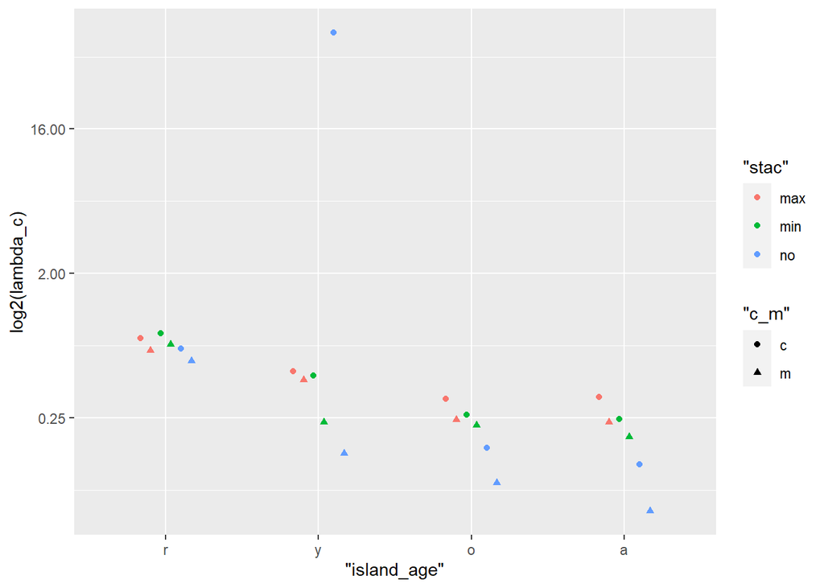

```r
ggplot2::ggplot(expanded_table_odeint, aes(x = `"island_age"`, y = lambda_c)) +
  geom_point(aes(color = `"stac"`, shape = `"c_m"`), position = position_dodge(0.4)) +
  scale_y_continuous(trans = 'log2', name = "log2(lambda_c)")
```

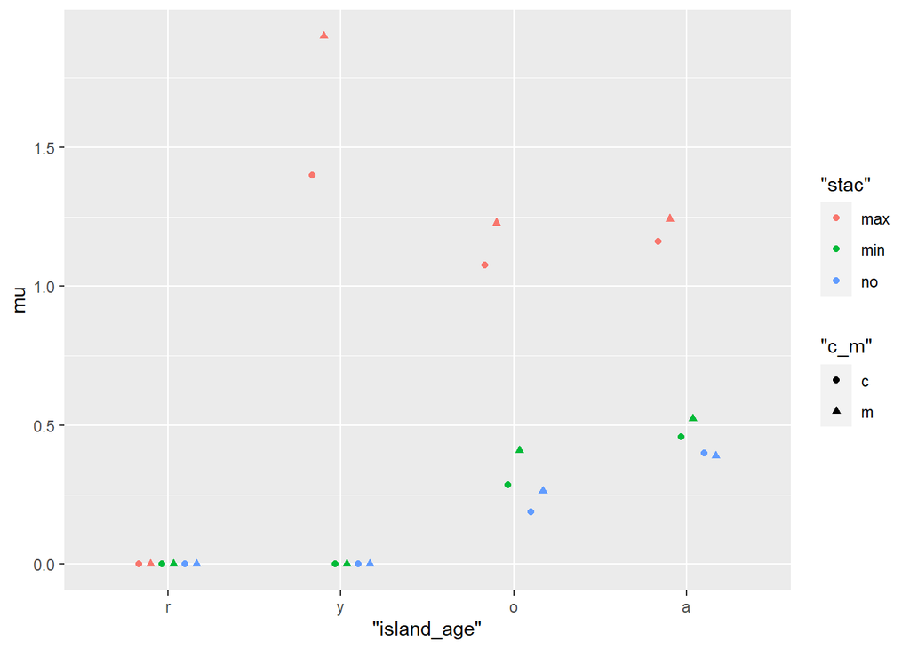

```r
ggplot2::ggplot(expanded_table_odeint, aes(x = `"island_age"`, y = mu)) +
  geom_point(aes(color = `"stac"`, shape = `"c_m"`), position = position_dodge(0.4))
```

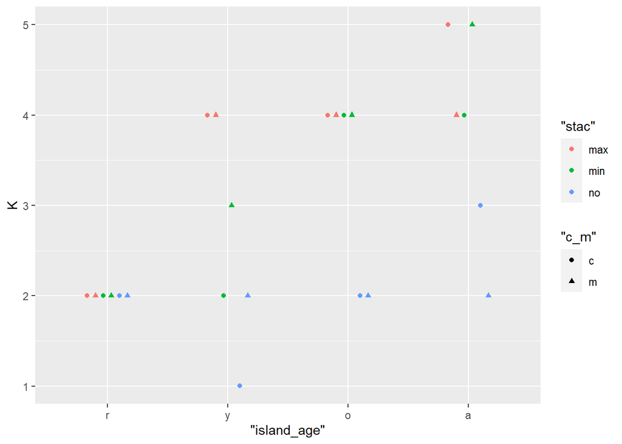

```r
ggplot2::ggplot(expanded_table_odeint, aes(x = `"island_age"`, y = K)) +
  geom_point(aes(color = `"stac"`, shape = `"c_m"`), position = position_dodge(0.4))
```

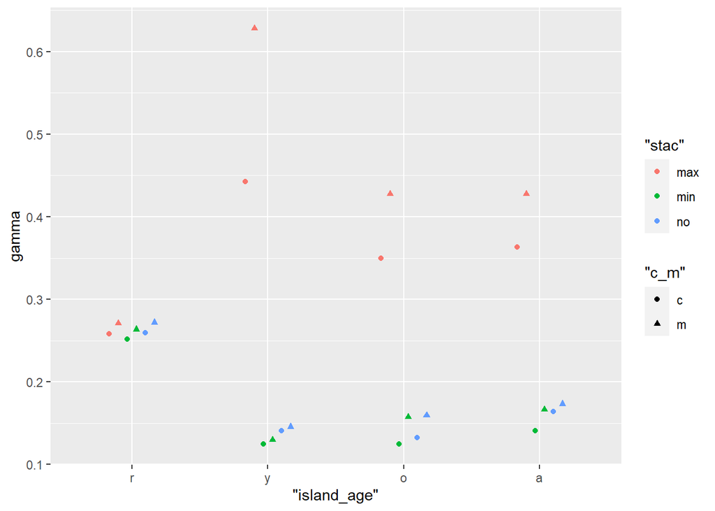

```r
ggplot2::ggplot(expanded_table_odeint, aes(x = `"island_age"`, y = gamma)) +
  geom_point(aes(color = `"stac"`, shape = `"c_m"`), position = position_dodge(0.4))
```

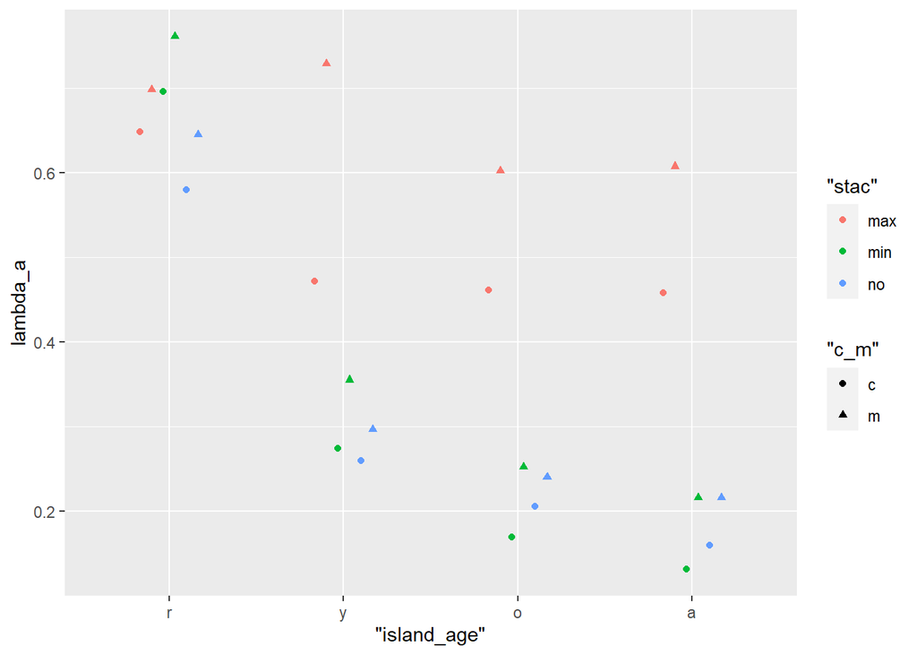

```r
ggplot2::ggplot(expanded_table_odeint, aes(x = `"island_age"`, y = lambda_a)) +
  geom_point(aes(color = `"stac"`, shape = `"c_m"`), position = position_dodge(0.4))
```

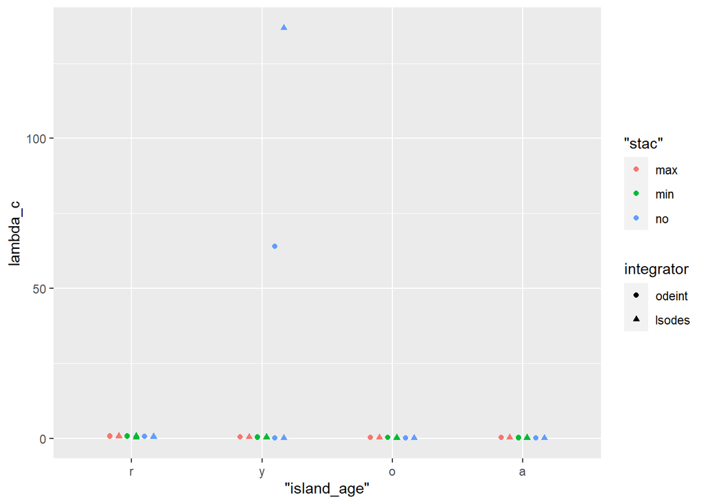

```r
ggplot2::ggplot(expanded_table, aes(x = `"island_age"`, y = lambda_c)) +
  geom_point(aes(color = `"stac"`, shape = integrator), position = position_dodge(0.4))
```

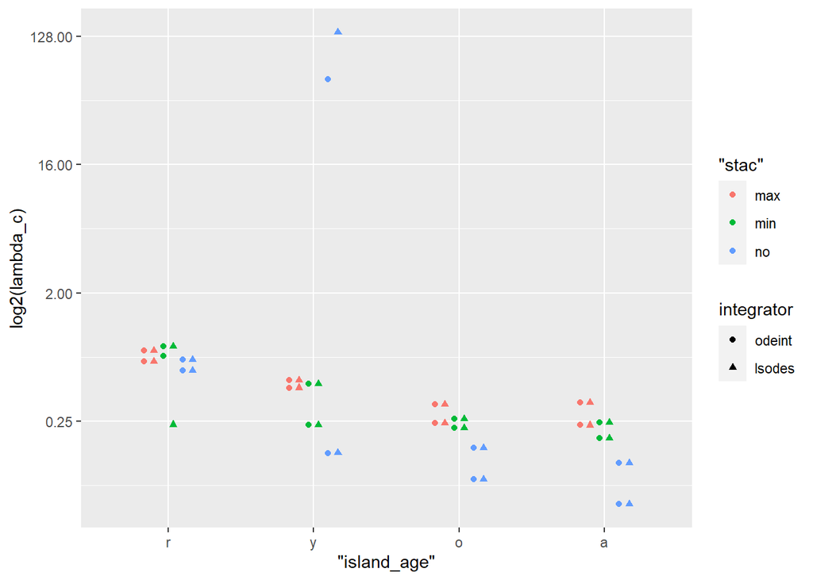

```r
ggplot2::ggplot(expanded_table, aes(x = `"island_age"`, y = lambda_c)) +
  geom_point(aes(color = `"stac"`, shape = integrator), position = position_dodge(0.4)) +
  scale_y_continuous(trans = 'log2', name = "log2(lambda_c)")
```

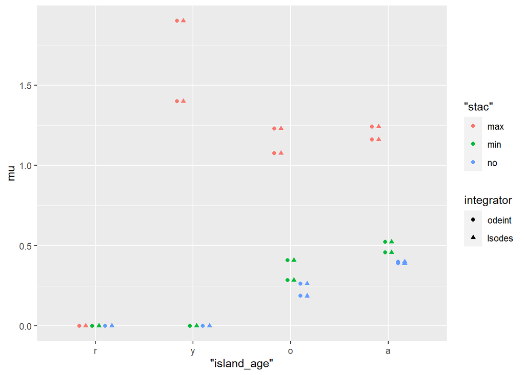

```r
ggplot2::ggplot(expanded_table, aes(x = `"island_age"`, y = mu)) +
  geom_point(aes(color = `"stac"`, shape = integrator), position = position_dodge(0.4))
```

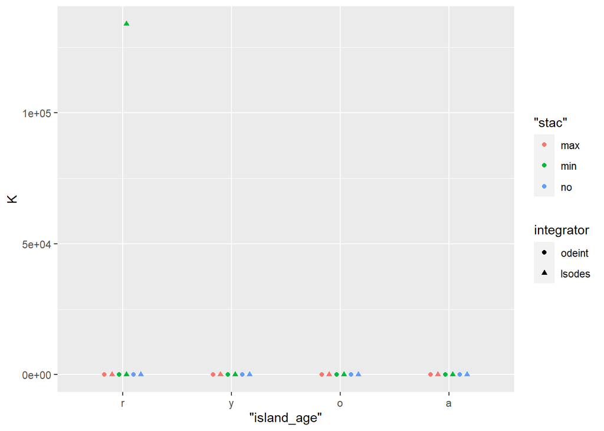

```r
ggplot2::ggplot(expanded_table, aes(x = `"island_age"`, y = K)) +
  geom_point(aes(color = `"stac"`, shape = integrator), position = position_dodge(0.4))
```

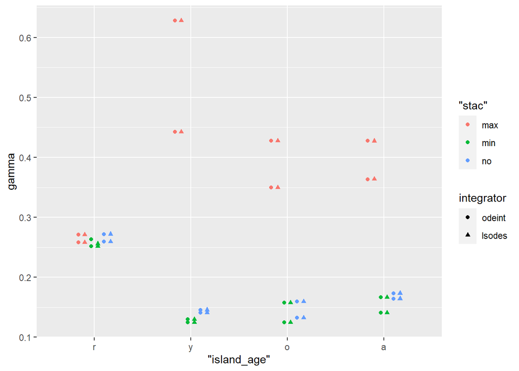

```r
ggplot2::ggplot(expanded_table, aes(x = `"island_age"`, y = gamma), position = position_dodge(0.4)) +
  geom_point(aes(color = `"stac"`, shape = integrator), position = position_dodge(0.4))
```

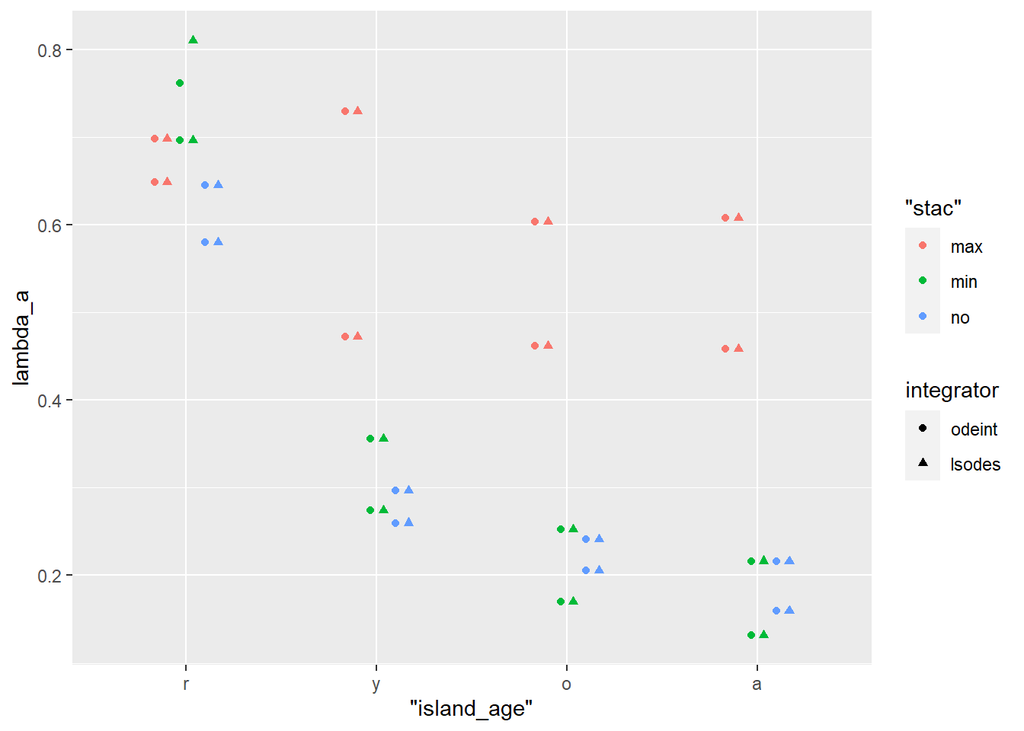

```r
ggplot2::ggplot(expanded_table, aes(x = `"island_age"`, y = lambda_a)) +
  geom_point(aes(color = `"stac"`, shape = integrator), position = position_dodge(0.4))
```

```r
knitr::kable(aggregate(. ~ scenario, res, FUN = diff)) %>%
  kableExtra::kable_styling() %>%
  kableExtra::footnote(
    general = "Difference between estimates obtained by different numeric integrators"
  )
```

| scenario | lambda_c | mu | K | gamma | lambda_a | loglik | df | conv | bic | integrator |
| --- | --- | --- | --- | --- | --- | --- | --- | --- | --- | --- |
| a_c_max | 0.0002264 | 0.0005462 | 5.000000e-07 | 0.0001720 | 0.0001745 | -0.0000011 | 0 | 0 | 0.0000022 | 1 |
| a_c_min | 0.0000052 | -0.0001088 | -1.000000e-07 | 0.0000118 | -0.0000189 | 0.0000006 | 0 | 0 | -0.0000012 | 1 |
| a_c_no | -0.0000300 | -0.0000682 | 3.600000e-06 | 0.0000010 | -0.0000505 | -0.0000030 | 0 | 0 | 0.0000061 | 1 |
| a_m_max | -0.0002030 | -0.0009817 | 2.300000e-06 | -0.0003616 | -0.0002937 | -0.0000032 | 0 | 0 | 0.0000065 | 1 |
| a_m_min | 0.0000352 | -0.0000039 | 2.400000e-06 | -0.0000092 | -0.0000402 | -0.0000001 | 0 | 0 | 0.0000001 | 1 |
| a_m_no | 0.0000598 | -0.0000731 | -8.000000e-07 | -0.0000336 | -0.0000305 | 0.0000007 | 0 | 0 | -0.0000014 | 1 |
| o_c_max | -0.0000114 | 0.0001307 | 1.000000e-07 | 0.0000672 | 0.0000093 | -0.0000002 | 0 | 0 | 0.0000004 | 1 |
| o_c_min | -0.0000682 | -0.0004278 | 1.000000e-07 | -0.0000792 | 0.0000275 | 0.0000006 | 0 | 0 | -0.0000013 | 1 |
| o_c_no | -0.0000161 | -0.0000027 | -1.000000e-07 | -0.0000008 | -0.0000106 | 0.0000001 | 0 | 0 | -0.0000003 | 1 |
| o_m_max | -0.0000767 | 0.0000611 | -3.000000e-07 | 0.0000023 | 0.0000556 | 0.0000004 | 0 | 0 | -0.0000008 | 1 |
| o_m_min | 0.0001522 | 0.0009243 | -6.000000e-07 | 0.0001734 | -0.0000159 | -0.0000085 | 0 | 0 | 0.0000171 | 1 |
| o_m_no | 0.0000107 | -0.0000041 | 0.000000e+00 | -0.0000024 | -0.0000034 | -0.0000001 | 0 | 0 | 0.0000002 | 1 |
| r_c_max | -0.0000591 | -0.0000011 | 4.000000e-07 | 0.0000080 | -0.0000377 | 0.0000021 | 0 | 0 | -0.0000041 | 1 |
| r_c_min | -0.0000407 | 0.0000000 | 4.000000e-07 | -0.0000034 | -0.0000033 | 0.0000005 | 0 | 0 | -0.0000011 | 1 |
| r_c_no | 0.0000752 | 0.0000002 | 0.000000e+00 | 0.0000048 | 0.0001003 | -0.0000008 | 0 | 0 | 0.0000016 | 1 |
| r_m_max | 0.0000049 | -0.0000013 | 4.000000e-07 | -0.0000135 | 0.0000136 | 0.0000027 | 0 | 0 | -0.0000055 | 1 |
| r_m_min | -0.4806755 | 0.0000000 | 1.339711e+05 | -0.0077710 | 0.0485081 | -0.8011271 | 0 | 0 | 1.6022543 | 1 |
| r_m_no | 0.0000825 | -0.0000002 | 1.000000e-07 | 0.0000013 | 0.0000907 | 0.0000009 | 0 | 0 | -0.0000018 | 1 |
| y_c_max | -0.0000225 | 0.0000090 | -1.000000e-07 | -0.0000100 | -0.0000003 | 0.0000000 | 0 | 0 | -0.0000001 | 1 |
| y_c_min | 0.0000130 | -0.0000004 | -2.000000e-07 | -0.0000182 | 0.0000169 | 0.0000060 | 0 | 0 | -0.0000120 | 1 |
| y_c_no | 72.7344296 | 0.0000019 | -1.032300e-03 | 0.0000373 | 0.0000195 | 0.0016611 | 0 | 0 | -0.0033222 | 1 |
| y_m_max | -0.0001632 | -0.0005900 | 0.000000e+00 | -0.0001514 | -0.0001618 | 0.0000003 | 0 | 0 | -0.0000006 | 1 |
| y_m_min | -0.0000353 | -0.0000008 | -1.210000e-05 | -0.0000165 | 0.0000202 | -0.0000017 | 0 | 0 | 0.0000034 | 1 |
| y_m_no | 0.0001603 | -0.0000008 | 0.000000e+00 | 0.0000106 | -0.0000334 | 0.0000023 | 0 | 0 | -0.0000046 | 1 |

Note:  
Difference between estimates obtained by different numeric integrators

## Scenario descriptions

| Scenario | Island Age | Favour cladogenesis | Favour MaxAge |
| --- | --- | --- | --- |
| r_c_max | 1.2My | Yes | Yes |
| r_c_min | 1.2My | Yes | MinAge |
| r_c_no | 1.2My | Yes | Never |
| y_c_max | 2.4My | Yes | Yes |
| y_c_min | 2.4My | Yes | MinAge |
| y_c_no | 2.4My | Yes | Never |
| o_c_max | 3.6My | Yes | Yes |
| o_c_min | 3.6My | Yes | MinAge |
| o_c_no | 3.6My | Yes | Never |
| a_c_max | 4.8My | Yes | Yes |
| a_c_min | 4.8My | Yes | MinAge |
| a_c_no | 4.8My | Yes | Never |
| r_m_max | 1.2My | No | Yes |
| r_m_min | 1.2My | No | MinAge |
| r_m_no | 1.2My | No | Never |
| y_m_max | 2.4My | No | Yes |
| y_m_min | 2.4My | No | MinAge |
| y_m_no | 2.4My | No | Never |
| o_m_max | 3.6My | No | Yes |
| o_m_min | 3.6My | No | MinAge |
| o_m_no | 3.6My | No | Never |
| a_m_max | 4.8My | No | Yes |
| a_m_min | 4.8My | No | MinAge |
| a_m_no | 4.8My | No | Never |

In scenarios favouring MaxAge the colonisation time is always assumed to be an upper limit, rather than a precise age, even when a precise age can be estimated from the data. While some information is lost in this process, the upside lies in accounting for possible uncertainty when inferring the phylogeny or interpreting it for the data pre processing step. A MinAge functions as a lower boundary for uncertain colonisation times. This lower limit corresponds to the earliest split between two populations of the same species. This ensures that uncertain colonisations (i.e., those considered MaxAge) have both an upper (MaxAge) and lower (MinAge) boundary, thus decreasing the assumed uncertainty in the phylogeny. MinAge favouring in the MaxAge column implies that MaxAgeMinAges are used when a min age is available and the precise colonisation time is available too. Not (never) favouring MaxAge means MinAges are used only **iff** the precise colonisation age is unknown and a min age is available. These are the “_no” scenarios, which are arguably the most realistic ones from an empirical point of view.